# Nobel Prize Analysis

**Challenge 1**: Preliminary data

```python
import pandas as pd
import matplotlib.pyplot as plt
import seaborn as sns
import plotly.express as px
from IPython.display import Markdown, display

df_data = pd.read_csv("data/nobel_prize_data.csv")
```

- What is the shape of df_data? How many rows and columns?

```python
print(f"The dataframe has sape {df_data.shape}.")
```

```
The dataframe has sape (962, 16).
```

- What are the column names and what kind of data is inside of them?

```python
print(f"The names of columns are: {list(df_data.columns)}.")
```

```
The names of columns are: ['year', 'category', 'prize', 'motivation', 'prize_share', 'laureate_type', 'full_name', 'birth_date', 'birth_city', 'birth_country', 'birth_country_current', 'sex', 'organization_name', 'organization_city', 'organization_country', 'ISO'].
```

- In which year was the Nobel prize first awarded?

```python
print(f"The first year the Nobel Prize was awarded was {df_data.year.min()}.")
```

```
The first year the Nobel Prize was awarded was 1901.
```

- Which year is the latest year included in the dataset?

```python
print(f"The last year included in the dataset is {df_data.year.max()}.")
```

```
The last year included in the dataset is 2020.
```

**Challenge 2**:

- Are there any duplicate values in the dataset?

```python
print(f"There are {df_data.duplicated().sum()} duplicate rows in the data.")
```

```
There are 0 duplicate rows in the data.
```

- Are there NaN values in the dataset?

```python
nan_values = df_data.isna().sum()
print(f"The number of NaN values in the dataset is {nan_values.sum()}.")
```

```
The number of NaN values in the dataset is 1023.
```

- Which columns tend to have NaN values?

```python
print(f"The columns with more than 200 NaN values are: {list(nan_values[nan_values > 200].index)}.")
```

```
The columns with more than 200 NaN values are: ['organization_name', 'organization_city', 'organization_country'].
```

- How many NaN values are there per column?

```python
display(Markdown(nan_values.to_markdown()))
```

|  | 0 |
| --- | --- |
| year | 0 |
| category | 0 |
| prize | 0 |
| motivation | 88 |
| prize_share | 0 |
| laureate_type | 0 |
| full_name | 0 |
| birth_date | 28 |
| birth_city | 31 |
| birth_country | 28 |
| birth_country_current | 28 |
| sex | 28 |
| organization_name | 255 |
| organization_city | 255 |
| organization_country | 254 |
| ISO | 28 |

- Why do these columns have NaN values?

```python
print("The columns related to organization may have NaNs because of winners without an affiliation with an organization")
print("The records without 'motivation' are peace prices.")
```

```
The columns related to organization may have NaNs because of winners without an affiliation with an organization
The records without 'motivation' are peace prices.
```

**Challenge 3**:

- Convert the birth_date column to Pandas Datetime objects

```python
df_data["birth_date"] = pd.to_datetime(df_data["birth_date"], format = "%Y-%m-%d")
```

- Add a Column called share_pct which has the laureates' share as a percentage in the form of a floating-point number.

```python
df_data["share_pct"] = df_data["prize_share"].apply(lambda x: eval(x))
```

# plotly Bar & Donut Charts: Analyse Prize Categories & Women Winning Prizes

**Challenge 1**: Come up with 3 Questions

A big part of data science is coming up with questions that you'd like to explore. This is the most difficult aspect to teach in a tutorial because it's completely open-ended and requires some creativity. Often times you will be asking questions of the data, that it actually cannot answer - and that's ok. That's all part of the process of discovery.

Pause here for a moment and think about the kind of data you saw in the columns. Write down at least 3 questions that you'd like to explore as part of this analysis. For example, your question might go like: “What percentage of the Nobel laureates were women?” or “How many prizes were given out in each category”. Practice coming up with a few of your own questions.

In the upcoming lessons, you might find that we will write the code to answer some of your questions. And if not, your questions make for a great exercise to take this analysis even further.

The challenges below are all based on questions we're going to ask the data:

**Challenge 2**: Create a donut chart using plotly which shows how many prizes went to men compared to how many prizes went to women. What percentage of all the prizes went to women?

```python
gender = df_data[~df_data["sex"].isna()].groupby(by = "sex", as_index = False).size()
gender.columns = ["Sex", "Awardees"]
gender_plot = px.pie(gender, names = gender.Sex, values = gender.Awardees, hole = .3)
gender_plot.show()
```

[interactive chart not shown]

**Challenge 3**:

- What are the names of the first 3 female Nobel laureates?

```python
first_females = df_data.sort_values("year").query('sex == "Female"').head(3)[["full_name", "motivation", "birth_country", "organization_name"]]
display(Markdown(first_females.to_markdown(index = False)))
```

| full_name | motivation | birth_country | organization_name |
| --- | --- | --- | --- |
| Marie Curie, née Sklodowska | “in recognition of the extraordinary services they have rendered by their joint researches on the radiation phenomena discovered by Professor Henri Becquerel” | Russian Empire (Poland) | nan |
| Baroness Bertha Sophie Felicita von Suttner, née Countess Kinsky von Chinic und Tettau | nan | Austrian Empire (Czech Republic) | nan |
| Selma Ottilia Lovisa Lagerlöf | “in appreciation of the lofty idealism, vivid imagination and spiritual perception that characterize her writings” | Sweden | nan |

**Challenge 4**: Did some people get a Nobel Prize more than once? If so, who were they?

```python
more_once = df_data["full_name"].duplicated()
more_once_names = df_data[more_once]["full_name"]
more_once_winners = df_data[df_data["full_name"].isin(more_once_names)][["full_name", "year"]].sort_values("full_name")
display(Markdown(more_once_winners.to_markdown(index = False)))
```

| full_name | year |
| --- | --- |
| Comité international de la Croix Rouge (International Committee of the Red Cross) | 1917 |
| Comité international de la Croix Rouge (International Committee of the Red Cross) | 1944 |
| Comité international de la Croix Rouge (International Committee of the Red Cross) | 1963 |
| Frederick Sanger | 1958 |
| Frederick Sanger | 1980 |
| John Bardeen | 1956 |
| John Bardeen | 1972 |
| Linus Carl Pauling | 1954 |
| Linus Carl Pauling | 1962 |
| Marie Curie, née Sklodowska | 1903 |
| Marie Curie, née Sklodowska | 1911 |
| Office of the United Nations High Commissioner for Refugees (UNHCR) | 1954 |
| Office of the United Nations High Commissioner for Refugees (UNHCR) | 1981 |

**Challenge 5**:

- In how many categories are prizes awarded?

```python
print(f"The number of categories of the Nobel prize is {df_data[~df_data['category'].isna()]['category'].nunique()}.")
```

```
The number of categories of the Nobel prize is 6.
```

- Create a plotly bar chart with the number of prizes awarded by category.

```python
prizes_category = df_data.groupby("category", as_index = False).size().sort_values("size", ascending = False)
prizes_category.columns = ["Category", "Number of Prizes"]
prizes_category_plot = px.bar(prizes_category, x = prizes_category["Category"], y = prizes_category["Number of Prizes"])
prizes_category_plot.show()
```

[interactive chart not shown]

- Use the color scale called Aggrnyl to colour the chart, but don't show a color axis.

```python
display(Markdown("**I refuse to use two different scales to show the same variable!**"))
```

**I refuse to use two different scales to show the same variable!**

**Challenge 6**:

- When was the first prize in the field of Economics awarded?

```python
print(f'The first Nobel prize in Economics was awarded in {df_data[df_data["category"] == "Economics"]["year"].min()}.')
```

```
The first Nobel prize in Economics was awarded in 1969.
```

- Who did the prize go to?

```python
first_year_economics = df_data[df_data["category"] == "Economics"]["year"].min()
first_economics_names = df_data.query("category == 'Economics' & (year == @first_year_economics)")["full_name"]
print(f"The first economics Nobel prize was awarded to {list(first_economics_names)}.")
```

```
The first economics Nobel prize was awarded to ['Jan Tinbergen', 'Ragnar Frisch'].
```

**Challenge 7**: Create a plotly bar chart that shows the split between men and women by category.

```python
categories_gender = df_data.groupby(["sex", "category"], as_index = False).size()
categories_gender.columns = ["Sex", "Category", "Number of Awardees"]
categories_gender_plot = px.bar(categories_gender, x = categories_gender["Category"], y = categories_gender["Number of Awardees"], color = categories_gender["Sex"])
categories_gender_plot.update_xaxes(categoryorder='total descending')
categories_gender_plot.show()
```

[interactive chart not shown]

# Using Matplotlib to Visualise Trends over Time

Now let's look at how things have changed over time. This will give us a chance to review what we learnt about creating charts with two y-axes in Matplotlib and generating arrays with NumPy.

**Challenge 1**:

- Are more prizes awarded recently than when the prize was first created? Show the trend in awards visually.

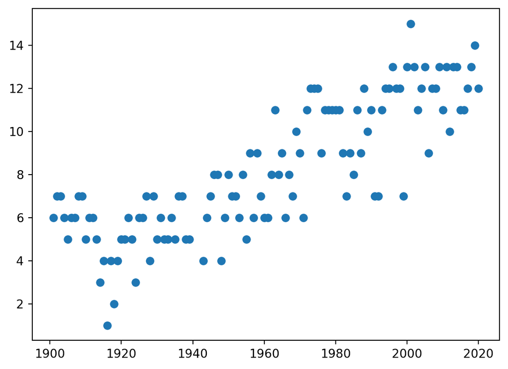

```python
prizes_year = df_data.groupby("year", as_index = False).size()
prizes_year.columns = ["Year", "Prizes Awarded"]
# this is plotly and worked well, but apparently the class required matplotlib
# prizes_year_plot = px.scatter(prizes_year, x = "Year", y = "Prizes Awarded", trendline="ols")
# prizes_year_plot.show()

# this is matplotlib
plt.scatter(x = prizes_year["Year"], y = prizes_year["Prizes Awarded"])
plt.show()
```

- Create a 5 year rolling average of the number of prizes (Hint: see previous lessons analysing Google Trends).

```python
prizes_ma5 = prizes_year.rolling(5).mean()
```

- Using Matplotlib superimpose the rolling average on a scatter plot.

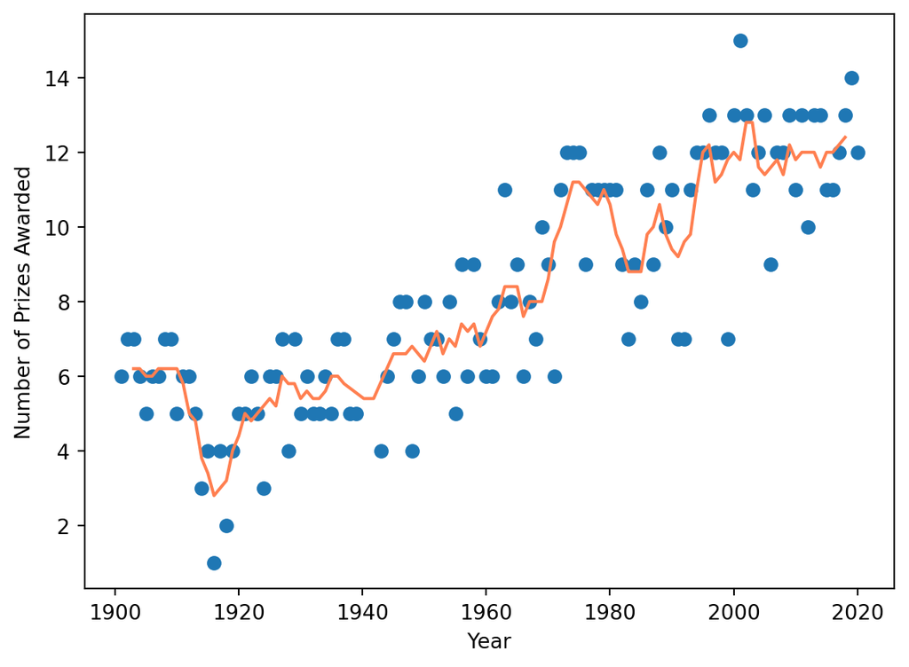

```python
f, ax = plt.subplots()
ax.scatter(prizes_year["Year"], y = prizes_year["Prizes Awarded"])
ax.plot(prizes_ma5["Year"].to_numpy(), prizes_ma5["Prizes Awarded"].to_numpy(), color = "coral")
plt.ylabel("Number of Prizes Awarded")
plt.xlabel("Year")
f.show()
```

- Show a tick mark on the x-axis for every 5 years from 1900 to 2020. (Hint: you'll need to use NumPy).

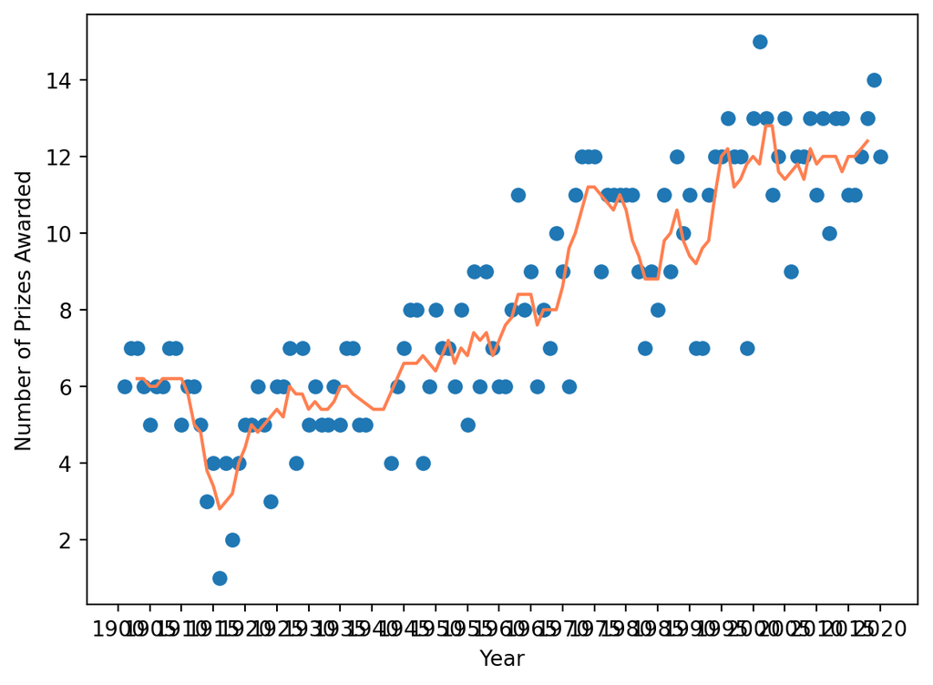

```python
import numpy as np

seq_5_year = np.arange(1900, 2021, 5)

f, ax = plt.subplots()
ax.scatter(prizes_year["Year"], y = prizes_year["Prizes Awarded"])
ax.plot(prizes_ma5["Year"].to_numpy(), prizes_ma5["Prizes Awarded"].to_numpy(), color = "coral")
plt.ylabel("Number of Prizes Awarded")
plt.xlabel("Year")
ax.set_xticks(seq_5_year)
f.show()
```

**Challenge 2**: Investigate if more prizes are shared than before.

- Calculate the average prize share of the winners on a year by year basis.

```python
prize_share = df_data.groupby("year", as_index = False)["share_pct"].mean()
```

- Calculate the 5 year rolling average of the percentage share.

```python
prize_share["rolling_share_pct"] = prize_share["share_pct"].rolling(5).mean()
```

- Copy-paste the cell from the chart you created above.

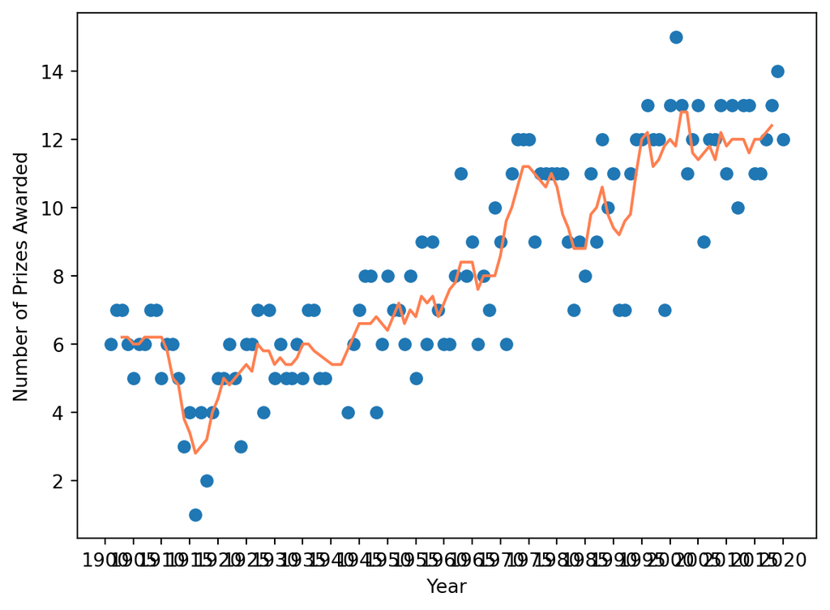

```python
f, ax = plt.subplots()
ax.scatter(prizes_year["Year"], y = prizes_year["Prizes Awarded"])
ax.plot(prizes_ma5["Year"].to_numpy(), prizes_ma5["Prizes Awarded"].to_numpy(), color = "coral")
plt.ylabel("Number of Prizes Awarded")
plt.xlabel("Year")
ax.set_xticks(seq_5_year)
#f.show()
```

- Modify the code to add a secondary axis to your Matplotlib chart.

```python
ax2 = ax.twinx()
ax2.plot(prize_share["year"].to_numpy(), prize_share["rolling_share_pct"].to_numpy(), color = "seagreen")
ax2.set_ylabel("Rolling average of percent shared", color = "seagreen")
plt.show()
```

- Plot the rolling average of the prize share on this chart.
- See if you can invert the secondary y-axis to make the relationship even more clear.

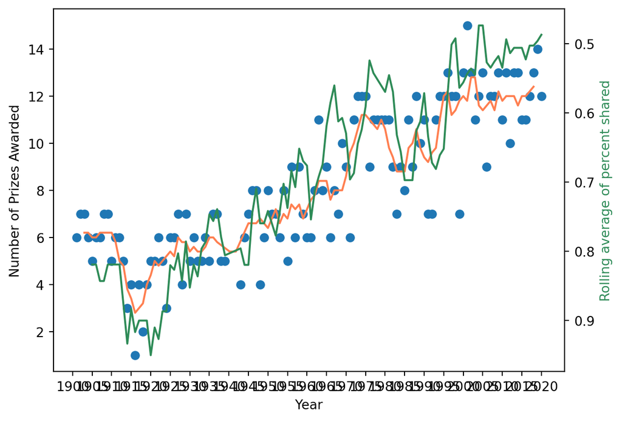

```python
f, ax = plt.subplots()
ax.scatter(prizes_year["Year"], y = prizes_year["Prizes Awarded"])
ax.plot(prizes_ma5["Year"].to_numpy(), prizes_ma5["Prizes Awarded"].to_numpy(), color = "coral")
plt.ylabel("Number of Prizes Awarded")
plt.xlabel("Year")
ax.set_xticks(seq_5_year)

ax2 = ax.twinx()
ax2.plot(prize_share["year"].to_numpy(), prize_share["rolling_share_pct"].to_numpy(), color = "seagreen")
ax2.set_ylabel("Rolling average of percent shared", color = "seagreen")

# this is the bit that inverts the axis
ax2.invert_yaxis()

plt.show()
```

# A Choropleth Map and the Countries with the Most Prizes

For this next bit, we're going to compare which countries actually get the most prizes. And we're also going to look at in which categories those prizes are awarded. This has me feeling a little like I'm at the Olympics 😊.

Challenge 1: Top 20 Country Ranking

- Create a Pandas DataFrame called top20_countries that has the two columns. The prize column should contain the total number of prizes won.

```python
prizes_countries = df_data.groupby("birth_country_current", as_index = False).size().sort_values("size", ascending = False)
prizes_countries.columns = ["Country", "Prize"]
top20_countries = prizes_countries.head(20)
```

- Then use plotly to create a horizontal bar chart showing the number of prizes won by each country. Here's what you're after:

```python
px.bar(top20_countries, y = "Country", x = "Prize", orientation = "h").show()
```

[interactive chart not shown]

**Challenge 2**: Choropleth Map

- Create this choropleth map using the plotly documentation:

```python
prizes_iso_country = df_data.groupby("ISO", as_index = False).size()
prizes_iso_country.columns = ["iso_alpha", "Prizes"]
df = px.data.gapminder().query("year==2007")

df = pd.merge(df, prizes_iso_country, on = "iso_alpha")
fig = px.choropleth(df, locations="iso_alpha",
                    color="Prizes",
                    hover_name="country", # column to add to hover information
                    color_continuous_scale=px.colors.sequential.OrRd)
fig.show()
```

[interactive chart not shown]

**Challenge 3**: Country Bar Chart with Prize Category

See if you can divide up the plotly bar chart you created above to show the which categories made up the total number of prizes. Here's what you're aiming for:

```python
prizes_countries_categories = df_data.groupby(["birth_country_current", "category"], as_index = False).size().sort_values("size", ascending = False)
prizes_countries_categories.columns = ["Country", "Category", "Prize"]
top20_countries_categories = prizes_countries_categories[prizes_countries_categories["Country"].isin(list(top20_countries["Country"]))]

countries_categories_plot = px.bar(top20_countries_categories, y = "Country", x = "Prize", color = "Category", orientation = "h")
countries_categories_plot.update_yaxes(categoryorder='total descending')
countries_categories_plot.show()
```

[interactive chart not shown]

**Challenge 4**: Prizes by Country over Time

Every country's fortunes wax and wane over time. Investigate how the total number of prizes awarded changed over the years.

- When did the United States eclipse every other country in terms of the number of prizes won?
- Which country or countries were leading previously?
- Calculate the cumulative number of prizes won by each country in every year. Again, use the birth_country_current of the winner to calculate this.
- Create a plotly line chart where each country is a coloured line.

```python
countries_trend = df_data.groupby(["birth_country_current", "year"], as_index = False).agg({"prize": pd.Series.count}).sort_values(["birth_country_current", "year"])
countries_trend["Cumulative prizes"] = countries_trend.groupby("birth_country_current")["prize"].cumsum()
countries_trend.columns = ["Country", "Year", "Prizes", "Cumulative Prizes"]

px.line(countries_trend, x = "Year", y = "Cumulative Prizes", color = "Country").show()
```

[interactive chart not shown]

# Create Sunburst Charts for a Detailed Regional Breakdown of Research Locations

**Challenge 1**: Many Nobel laureates are affiliated with a university, a laboratory, or a research organisation (apart from Literature and Peace prize winners as we've seen). But the world is a big place. Which research institutions had the most Nobel laureates working there at the time of making the discovery?

- Create a bar chart showing the organisations affiliated with the Nobel laureates. It should looks something like this:
- Which organisations make up the top 20?
- How many Nobel prize winners are affiliated with the University of Chicago and Harvard University?

```python
organizations = df_data.groupby("organization_name", as_index = False).agg({"prize": pd.Series.count}).sort_values("prize", ascending = False)
px.bar(organizations.head(20), "organization_name", "prize").show()
```

[interactive chart not shown]

**Challenge 2**: Each research organisation is located in a particular city. Are some cities hot spots for scientific discoveries? Where do major discoveries tend to take place?

- Create another plotly bar chart graphing the top 20 organisation cities of the research institutions associated with a Nobel laureate.
- Where is the number one hotspot for discoveries in the world?
- Which city in Europe has had the most discoveries?

```python
cities = df_data.groupby("organization_city", as_index = False).agg({"prize": pd.Series.count}).sort_values("prize", ascending = False)
px.bar(cities.head(20), "organization_city", "prize").show()
```

[interactive chart not shown]

**Challenge 3**: Contrast the above chart with the birth city of the Nobel laureates. Would you expect to see a similar ranking for where the laureates are born versus where most discoveries are made? Would you expect to see the most populous cities producing the highest number of Nobel laureates?

- Create a plotly bar chart graphing the top 20 birth cities of Nobel laureates.
- Use a named colour scale called Plasma for the chart.
- What percentage of the United States prizes came from Nobel laureates born in New York?
- How many Nobel laureates were born in London, Paris and Vienna?
- Out of the top 5 cities, how many are in the United States?

```python
birth_cities = df_data.groupby("birth_city", as_index = False).agg({"prize": pd.Series.count}).sort_values("prize", ascending = False)
px.bar(birth_cities.head(20), "birth_city", "prize").show()
```

[interactive chart not shown]

**Challenge 4**: Create a DataFrame that groups the number of prizes by organisation.

- Then use the plotly documentation to create a sunburst chart
- Click around in your chart, what do you notice about Germany and France?

```python
organization_detail = df_data.groupby(["organization_country", "organization_city", "organization_name"], as_index = False).agg({"prize": pd.Series.count})
organization_detail.rename(columns = {"organization_country": "Country", "organization_city": "City", "organization_name": "Organization"}, inplace = True)
sb = px.sunburst(organization_detail, path = ["Country", "City", "Organization"], values = "prize")
sb.show()
```

[interactive chart not shown]

# Unearthing Patterns in the Laureate Age at the Time of the Award

How old are the Nobel laureates at the time when they win the prize? Does this vary by category? Also, how has the age of the laureates changed over time?

**Challenge 1**: Calculate the age of the laureate in the year of the ceremony and add this as a column called winning_age to the df_data DataFrame. Hint: you can use this to help you.

```python
df_data["winning_age"] = df_data["year"] - df_data["birth_date"].dt.year
```

**Challenge 2**:

- What are the names of the youngest and oldest Nobel laureate?
- Who were the oldest and the youngest winners?

```python
max_age = df_data["winning_age"].max()
min_age = df_data["winning_age"].min()
print(f"The oldest winners were {df_data.query('winning_age == @max_age').full_name.iloc[0]}, who at the time of winning were {df_data.query('winning_age == @max_age')['winning_age'].iloc[0]}.")

print(f"The youngest winners were {df_data.query('winning_age == @min_age').full_name.iloc[0]}, who at the time of winning were {df_data.query('winning_age == @min_age')['winning_age'].iloc[0]}.")
```

```
The oldest winners were John Goodenough, who at the time of winning were 97.0.
The youngest winners were Malala Yousafzai, who at the time of winning were 17.0.
```

- What is the average age of a winner?

```python
print(f"The average age of the Nobel winner is {df_data['winning_age'].mean():.1f} years of age.")
```

```
The average age of the Nobel winner is 59.9 years of age.
```

- 75% of laureates are younger than what age when they receive the prize?

```python
print(f"The upper quartile of the age of winners is {df_data['winning_age'].quantile(.75):.1f} years of age.")
```

```
The upper quartile of the age of winners is 69.0 years of age.
```

- Use Seaborn to create histogram to visualise the distribution of laureate age at the time of winning. Experiment with the number of bins to see how the visualisation changes.

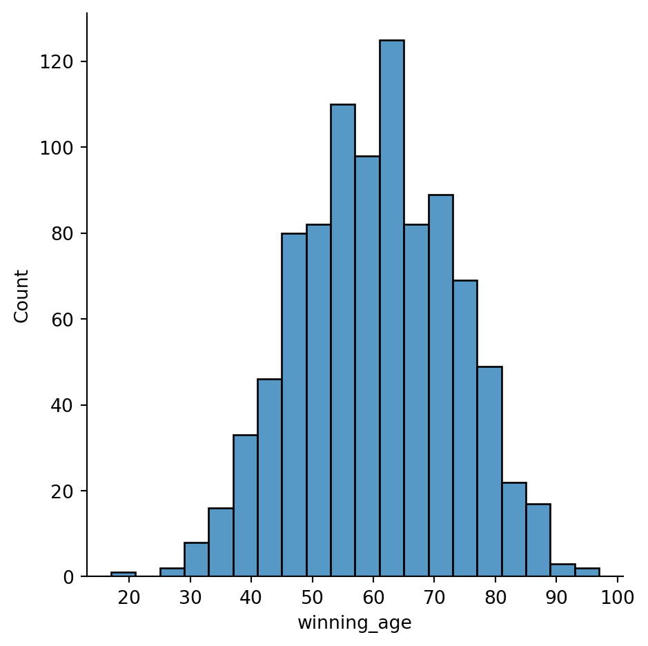

```python
sns.displot(df_data, x = "winning_age", bins = 20)
plt.show()
```

**Challenge 3**: Calculate the descriptive statistics for the age at the time of the award.

```python
display(Markdown(df_data["winning_age"].describe().to_markdown()))
```

|  | winning_age |
| --- | --- |
| count | 934 |
| mean | 59.9486 |
| std | 12.6178 |
| min | 17 |
| 25% | 51 |
| 50% | 60 |
| 75% | 69 |
| max | 97 |

**Challenge 4**: Are Nobel laureates being nominated later in life than before? Have the ages of laureates at the time of the award increased or decreased over time?

- Use Seaborn to create a .regplot with a trendline.
- Set the lowess parameter to True to show a moving average of the linear fit.
- According to the best fit line, how old were Nobel laureates in the years 1900-1940 when they were awarded the prize?
- According to the best fit line, what age would it predict for a Nobel laureate in 2020?

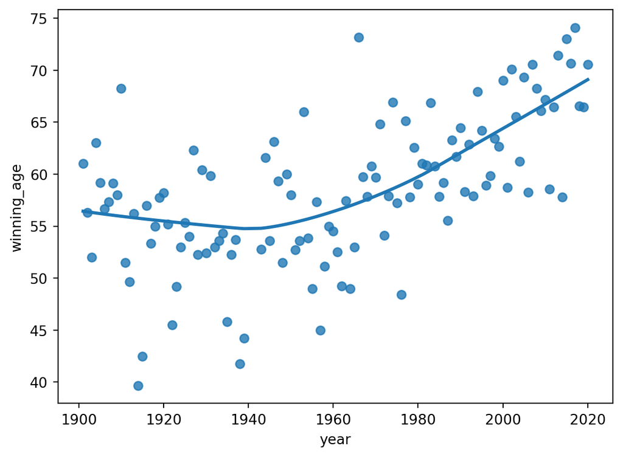

```python
age_years = df_data.groupby("year", as_index = False).agg({"winning_age": pd.Series.mean})
sns.regplot(age_years, x = "year", y = "winning_age", lowess = True)
plt.show()
```

**Challenge 5**: How does the age of laureates vary by category?

- Use Seaborn's .boxplot() to show how the mean, quartiles, max, and minimum values vary across categories. Which category has the longest “whiskers”?
- In which prize category are the average winners the oldest?
- In which prize category are the average winners the youngest?
- You can also use plotly to create the box plot if you like.

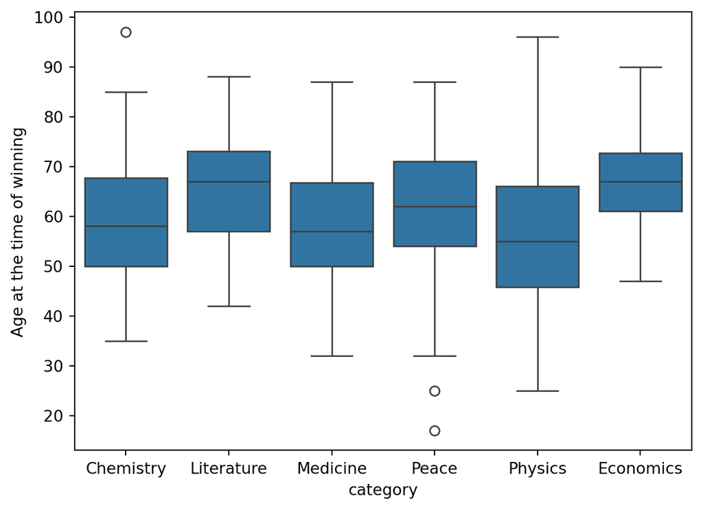

```python
sns.boxplot(df_data, x = "category", y = "winning_age")
plt.ylabel("Age at the time of winning")
plt.show()
```

**Challenge 6**: Now use Seaborn's .lmplot() and the row parameter to create 6 separate charts for each prize category. Again set lowess to True.

- What are the winning age trends in each category?
- Which category has the age trending up and which category has the age trending down?
- Is this .lmplot() telling a different story from the .boxplot()?
- Create a third chart with Seaborn. This time use .lmplot() to put all 6 categories on the same chart using the hue parameter.

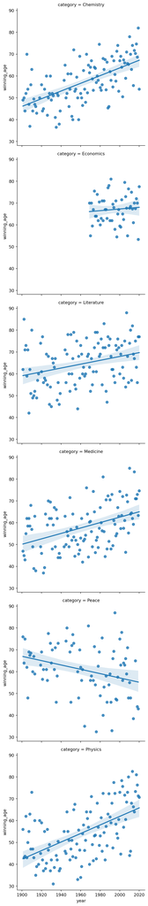

```python
age_categories = df_data.groupby(["category", "year"], as_index = False).agg({"winning_age": pd.Series.mean})
sns.lmplot(age_categories, x = "year", y = "winning_age", row = "category")
plt.show()
```

```python
fig = px.scatter(age_categories, x= "year", y = "winning_age", facet_col = "category", facet_col_wrap = 2, trendline = "ols", labels = {"winning_age": "Age at the time of winning"})
fig.for_each_annotation(lambda a: a.update(text=a.text.split("=")[-1]))

fig.show()
```

[interactive chart not shown]